# Primo blocco di esercizi TAD 2018/19

## 6. Numeri generati da una poisson

### A) Simulato con algoritmo derivante dalle proprietà del processo di poisson

### 1000 Determinazioni simulate

```r
n=1000
lambda=2.74
det1PS=vector(mode="numeric")

for (i in 1:n){
  m=-1
  a = 1
  repeat {
    m =m +1
    b=a
    u=runif(1)
    a=a*u
      if (a<exp(-lambda) & exp(-lambda)<= b){
        detvect=m
        break
      }
    }
  det1PS[i]=detvect
}

#Indici sintetici
mean(det1PS)
```

```
## [1] 2.829
```

```r
var(det1PS)
```

```
## [1] 2.786546
```

```r
# Media e varianza teorica
lambda
```

```
## [1] 2.74
```

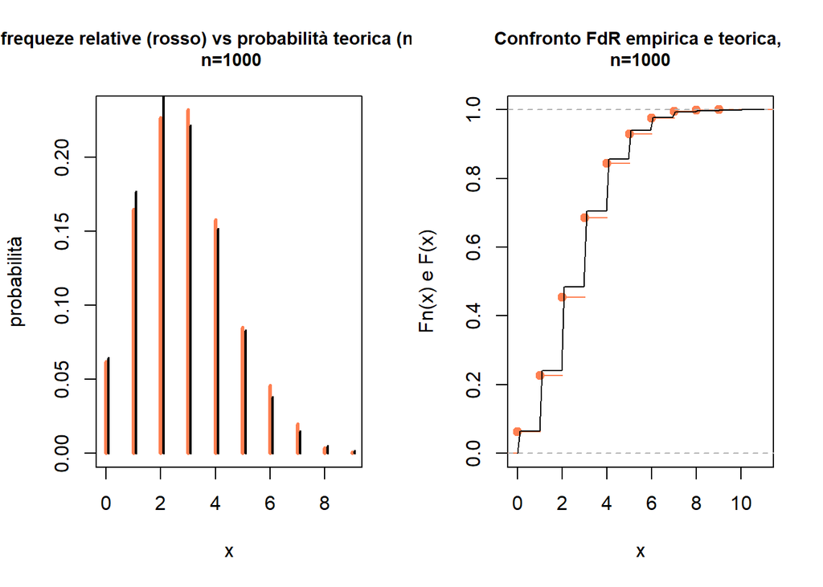

```r
par(mfrow=c(1,2))

## Funzione di densità
tab=table(det1PS)
tabo=as.data.frame(tab)
punti = as.numeric(levels(tabo$det1PS))
freq = as.numeric(tab/n)
plot(punti, freq, type="h", col="coral", ylab="probabilità", xlab="x",xlim=c(0,max(det1PS)), ylim=c(0,max(freq)), lwd=3,main="frequeze relative (rosso) vs probabilità teorica (nero), \n n=1000", cex.main=0.9)
points(punti+0.1 ,dpois(punti,lambda),type="h",col="black", lwd=2)

#Funzione di ripartizione
plot(ecdf(det1PS),xlim=c(0,max(det1PS)+2), col="coral", cex.main=0.9, main="Confronto FdR empirica e teorica, \nn=1000",xlab="x", ylab="Fn(x) e F(x)")
curve(ppois(x, lambda = lambda), col="black", add=TRUE)
```

```r
n=1000
lambda=2.74
det2PS=vector(mode="numeric")

for (i in 1:n){
  m=-1
  a = 1
  repeat {
    m =m +1
    b=a
    u=runif(1)
    a=a*u
      if (a<exp(-lambda) & exp(-lambda)<= b){
        detvect=m
        break
      }
    }
  det2PS[i]=detvect
}

#Indici sintetici
mean(det2PS)
```

```
## [1] 2.618
```

```r
var(det2PS)
```

```
## [1] 2.636713
```

```r
# Media e varianza teorica
lambda
```

```
## [1] 2.74
```

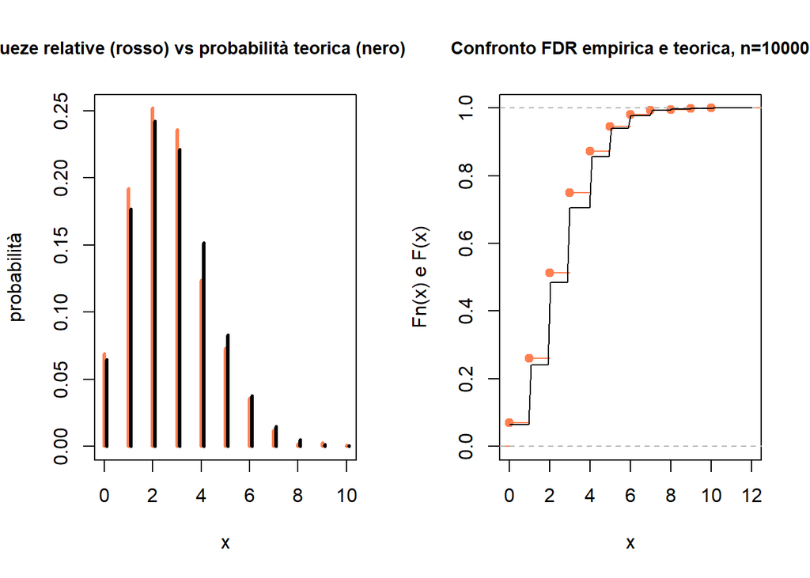

```r
par(mfrow=c(1,2))

# Funzione di densità
tab=table(det2PS)
tabo=as.data.frame(tab)
punti = as.numeric(levels(tabo$det2PS))
freq = as.numeric(tab/n)
plot(punti, freq, type="h", col="coral", ylab="probabilità", xlab="x",xlim=c(0,max(det2PS)), ylim=c(0,max(freq)), lwd=3,main="frequeze relative (rosso) vs probabilità teorica (nero), n=10000", cex.main=0.9)
points(punti+0.1,dpois(punti,lambda),type="h",col="black", lwd=3)

#Funzione di ripartizione
plot(ecdf(det2PS),xlim=c(0,max(det2PS)+2), col="coral", cex.main=0.9, main="Confronto FDR empirica e teorica, n=10000",xlab="x", ylab="Fn(x) e F(x)")
curve(ppois(x, lambda = lambda), col="black", add=TRUE)
```

### B) Simulato con algoritmi di r

```r
n=1000
det1=rpois(n, lambda)

#Indici sintetici
mean(det1)
```

```
## [1] 2.826
```

```r
var(det1)
```

```
## [1] 2.852577
```

```r
## Media e Varianza teorcia:
lambda
```

```
## [1] 2.74
```

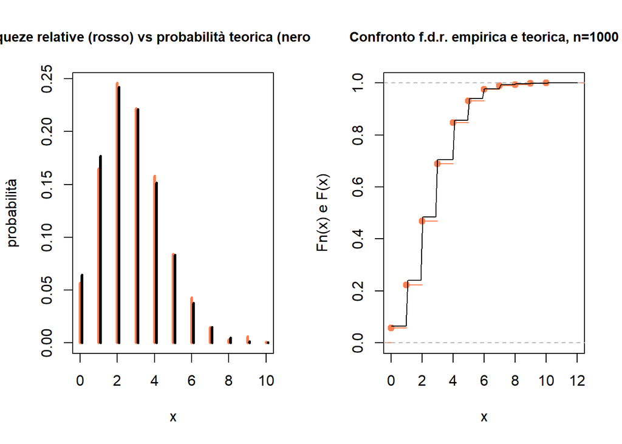

```r
par(mfrow=c(1,2))
# Funzione di densità
tab=table(det1)
tabo=as.data.frame(tab)
punti = as.numeric(levels(tabo$det1))
freq = as.numeric(tab/n)
plot(punti, freq, type="h", col="coral", ylab="probabilità", xlab="x",xlim=c(0,max(det1)), ylim=c(0,max(freq)), lwd=3,main="frequeze relative (rosso) vs probabilità teorica (nero), n=1000", cex.main=0.9)
points(punti+.1,dpois(punti,lambda),type="h",col="black", lwd=3)

#Funzione di ripartizione
plot(ecdf(det1),xlim=c(0,max(det1)+2), col="coral", cex.main=0.9,
     main="Confronto f.d.r. empirica e teorica, n=1000",xlab="x", ylab="Fn(x) e F(x)")
curve(ppois(x, lambda = lambda), col="black", add=TRUE)
```

### 10000 determinazioni simulate

```r
n=10000
det2=rpois(n, lambda)

#Inidici sintetici
mean(det2)
```

```
## [1] 2.7419
```

```r
var(det2)
```

```
## [1] 2.743959
```

```r
# Media e varianza teorica
lambda
```

```
## [1] 2.74
```

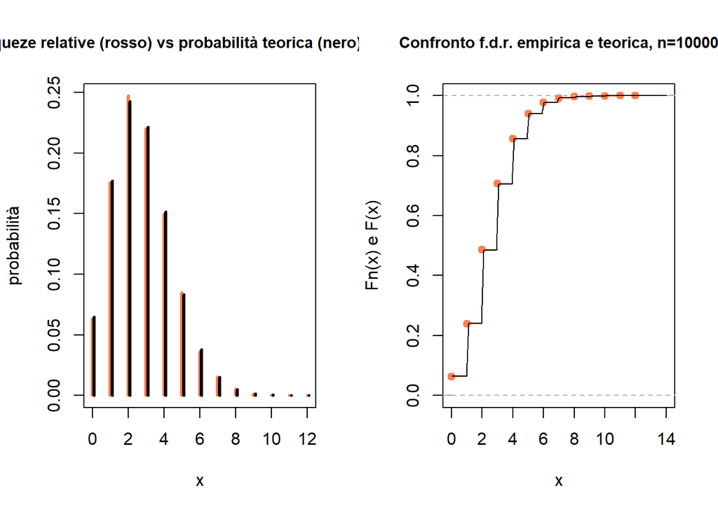

```r
par(mfrow=c(1,2))

# Funzione di densità
tab=table(det2)
tabo=as.data.frame(tab)
punti = as.numeric(levels(tabo$det2))
freq = as.numeric(tab/n)
plot(punti, freq, type="h", col="coral", ylab="probabilità", xlab="x",xlim=c(0,max(det2)), ylim=c(0,max(freq)), lwd=3,main="Frequeze relative (rosso) vs probabilità teorica (nero), n=10000", cex.main=0.9)
points(punti+ 0.1,dpois(punti,lambda),type="h",col="black", lwd=3)

#Funzione di ripartizione
plot(ecdf(det2),xlim=c(0,max(det2)+2), col="coral", cex.main=0.9, main="Confronto f.d.r. empirica e teorica, n=10000",xlab="x", ylab="Fn(x) e F(x)")
curve(ppois(x, lambda = lambda), col="black", add=TRUE)
```

### Confronta tra det1PS, det2PS, det1 e det2

```r
mean(det1)
```

```
## [1] 2.826
```

```r
mean(det2)
```

```
## [1] 2.7419
```

```r
mean(det1PS)
```

```
## [1] 2.829
```

```r
mean(det2PS)
```

```
## [1] 2.618
```

```r
var(det1)
```

```
## [1] 2.852577
```

```r
var(det2)
```

```
## [1] 2.743959
```

```r
var(det1PS)
```

```
## [1] 2.786546
```

```r
var(det2PS)
```

```
## [1] 2.636713
```

```r
tab1=table(det1)
tabo1=as.data.frame(tab1)
punti1 = as.numeric(levels(tabo1$det1))
freq1 = as.numeric(tab1/1000)

tab2=table(det2)
tabo2=as.data.frame(tab2)
punti2 = as.numeric(levels(tabo2$det2))
freq2 = as.numeric(tab2/10000)

tab1PS=table(det1PS)
tabo1PS=as.data.frame(tab1PS)
punti1PS = as.numeric(levels(tabo1PS$det1PS))
freq1PS = as.numeric(tab1PS/1000)

tab2PS=table(det2PS)
tabo2PS=as.data.frame(tab2PS)
punti2PS = as.numeric(levels(tabo2PS$det2PS))
freq2PS = as.numeric(tab2PS/10000)
```

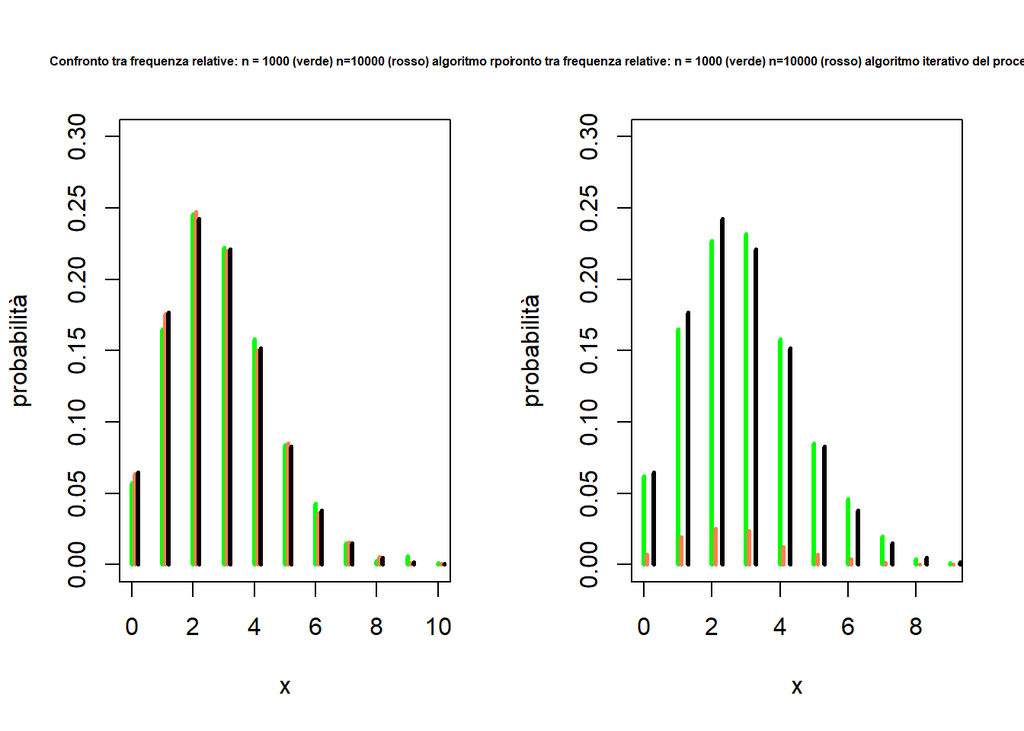

```r
# Cfr Funzioni di probabilità
par(mfrow=c(1,2))
plot(punti1, freq1, type="h", col="green", ylab="probabilità", xlab="x",xlim=c(0,max(det1)), ylim=c(0,0.3), lwd=3, main="Confronto tra frequenza relative: n = 1000 (verde) n=10000 (rosso) algoritmo rpois", cex.main=0.5)
points(punti2+.1, freq2, type="h", col="coral", lwd=3)
points(punti1+.2,dpois(punti1,lambda),type="h",col="black", lwd=3)

plot(punti1PS, freq1PS, type="h", col="green", ylab="probabilità", xlab="x", xlim=c(0,max(det1PS)), ylim=c(0,0.3), lwd=3, main="Confronto tra frequenza relative: n = 1000 (verde) n=10000 (rosso) algoritmo iterativo del processo stocastico", cex.main=0.5)
points(punti2PS+ 0.1, freq2PS, type="h", col="coral", lwd=3)
points(punti1PS+ 0.3,dpois(punti1PS,lambda),type="h",col="black", lwd=3)
```

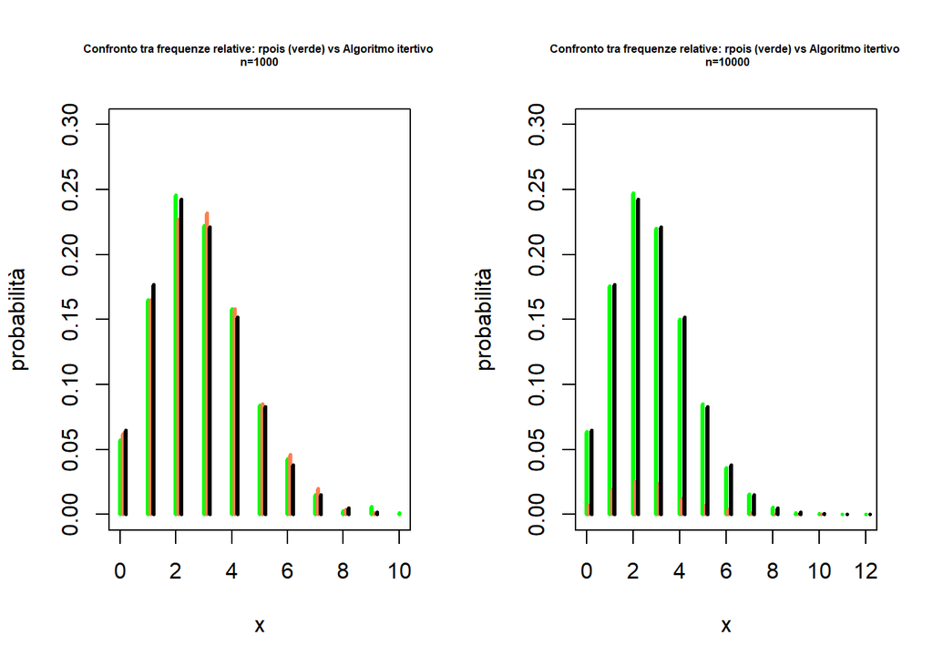

```r
plot(punti1, freq1, type="h", col="green", ylab="probabilità", xlab="x",xlim=c(0,max(det1)), ylim=c(0,0.3), lwd=3, main="Confronto tra frequenze relative: rpois (verde) vs Algoritmo itertivo \nn=1000", cex.main=0.5)
points(punti1PS+.1, freq1PS, type="h", col="coral", lwd=3)
points(punti1PS+.2,dpois(punti1PS,lambda),type="h",col="black", lwd=3)

plot(punti2, freq2, type="h", col="green", ylab="probabilità", xlab="x",xlim=c(0,max(det2)), ylim=c(0,0.3), lwd=3, main="Confronto tra frequenze relative: rpois (verde) vs Algoritmo itertivo \n n=10000", cex.main=0.5)
points(punti2PS+.1, freq2PS, type="h", col="coral", lwd=3)
points(punti2+.2,dpois(punti2,lambda),type="h",col="black", lwd=3)
```

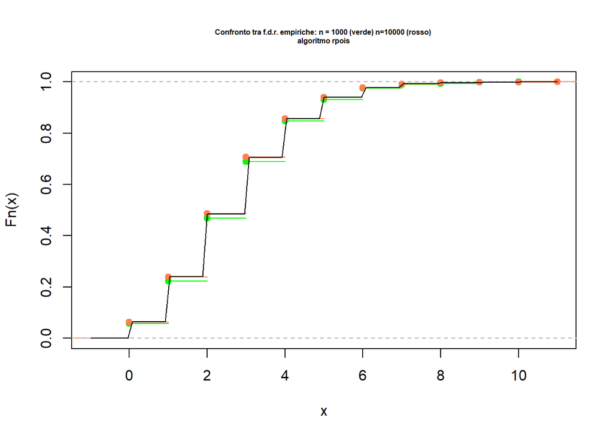

```r
# Cfr Funzioni di ripartizione
plot(ecdf(det1), col="green",
main="Confronto tra f.d.r. empiriche: n = 1000 (verde) n=10000 (rosso) \nalgoritmo rpois",
cex.main=0.5)
plot(ecdf(det2), col="coral", add=T)
curve(ppois(x,lambda), col="black", add=TRUE)
```

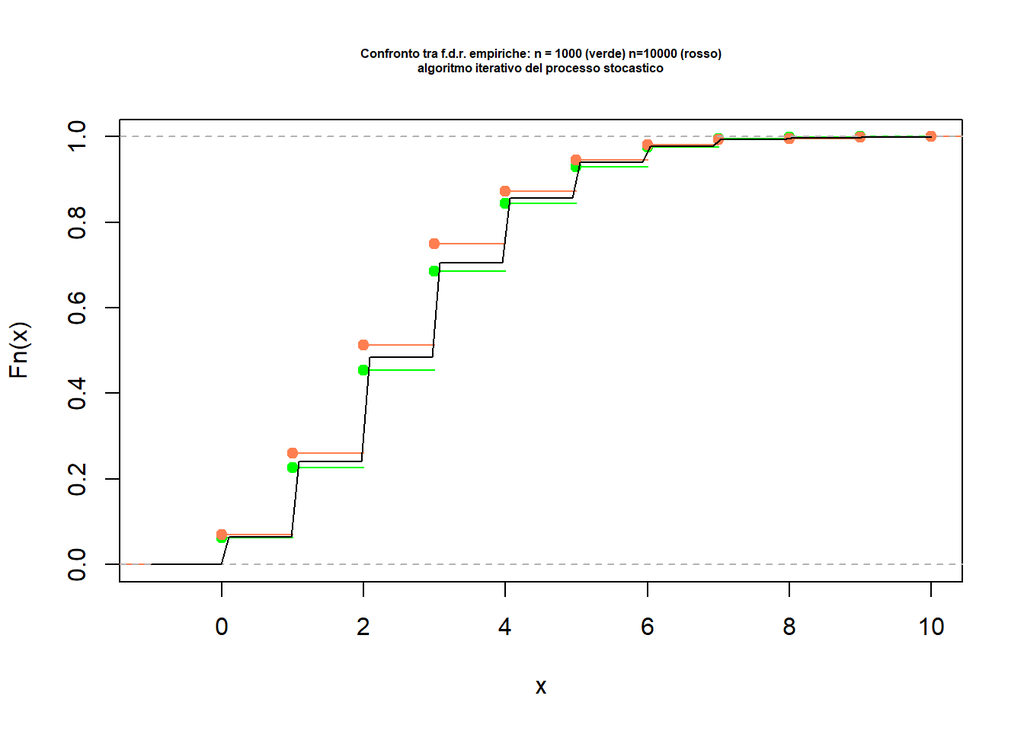

```r
plot(ecdf(det1PS), col="green",
main="Confronto tra f.d.r. empiriche: n = 1000 (verde) n=10000 (rosso)
algoritmo iterativo del processo stocastico", cex.main=0.5)
plot(ecdf(det2PS), col="coral", add=T)
curve(ppois(x,lambda), col="black", add=TRUE)
```

## 7. Disitribuzione Binomiale- Negativa

```r
# Indici sintetici
n=1000
alpha = 7.29
p=0.91
alpha/p
```

```
## [1] 8.010989
```

```r
det1=rnbinom(n,alpha ,p)
#Indici sintetici
mean(det1)
```

```
## [1] 0.728
```

```r
var(det1)
```

```
## [1] 0.7948108
```

```r
## Media e varianza teorica:
alpha*(1-p)/p #(vd details)
```

```
## [1] 0.720989
```

```r
alpha*(1-p)/p^2
```

```
## [1] 0.7922956
```

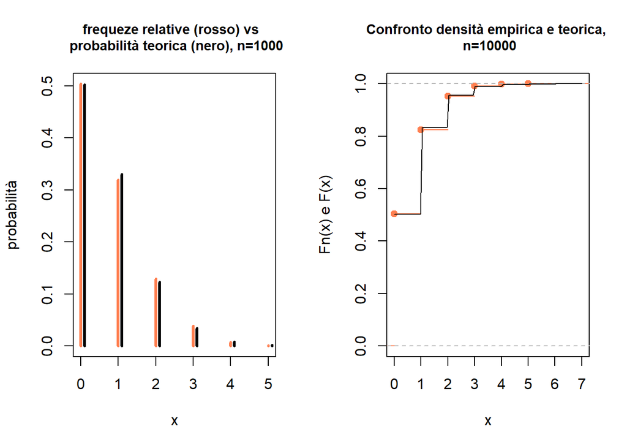

```r
par(mfrow=c(1,2))

## Funzione di densità
tab=table(det1)
tabo=as.data.frame(tab)
punti = as.numeric(levels(tabo$det1))
freq = as.numeric(tab/n)
plot(punti, freq, type="h", col="coral", ylab="probabilità", xlab="x",xlim=c(0,max(det1)), ylim=c(0,max(freq)), lwd=3,main="frequeze relative (rosso) vs  \n probabilità teorica (nero), n=1000", cex.main=0.9)
points(punti+0.1,dnbinom(punti,alpha, p),type="h",col="black", lwd=3)

#Funzione di ripartizione
plot(ecdf(det1),xlim=c(0,max(det1)+2), col="coral", cex.main=0.9, main="Confronto densità empirica e teorica, \n n=10000",xlab="x", ylab="Fn(x) e F(x)")
curve(pnbinom(x, alpha, p), col="black", add=TRUE)
```

### Per n=10000 determinazioni simulate

```r
# Indici sintetici
n=10000
alpha = 7.29
p=0.91
alpha/p
```

```
## [1] 8.010989
```

```r
det2=rnbinom(n,alpha ,p)
#Inidici sintetici
mean(det2)
```

```
## [1] 0.7201
```

```r
var(det2)
```

```
## [1] 0.789835
```

```r
## Media e varianza teorica:
alpha*(1-p)/p #(vd details)
```

```
## [1] 0.720989
```

```r
alpha*(1-p)/p^2
```

```
## [1] 0.7922956
```

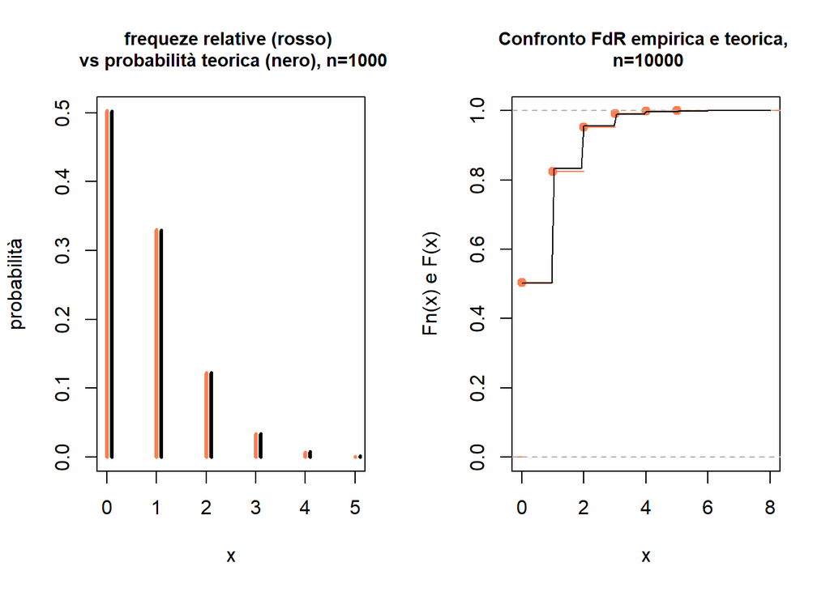

```r
par(mfrow=c(1,2))

## Funzione di densità
tab=table(det2)
tabo=as.data.frame(tab)
punti = as.numeric(levels(tabo$det2))
freq = as.numeric(tab/n)
plot(punti, freq, type="h", col="coral", ylab="probabilità", xlab="x",xlim=c(0,max(det1)), ylim=c(0,max(freq)), lwd=3,main="frequeze relative (rosso) \n vs probabilità teorica (nero), n=1000", cex.main=0.9)
points(punti+0.1,dnbinom(punti,alpha, p),type="h",col="black", lwd=3)

#Funzione di ripartizione
plot(ecdf(det1),xlim=c(0,max(det2)+2), col="coral", cex.main=0.9, main="Confronto FdR empirica e teorica, \n n=10000",xlab="x", ylab="Fn(x) e F(x)")
curve(pnbinom(x, alpha, p), col="black", add=TRUE)
```

### Confronto fra det1 e det2

```r
mean(det1)
```

```
## [1] 0.728
```

```r
mean(det1)
```

```
## [1] 0.728
```

```r
var(det1)
```

```
## [1] 0.7948108
```

```r
var(det2)
```

```
## [1] 0.789835
```

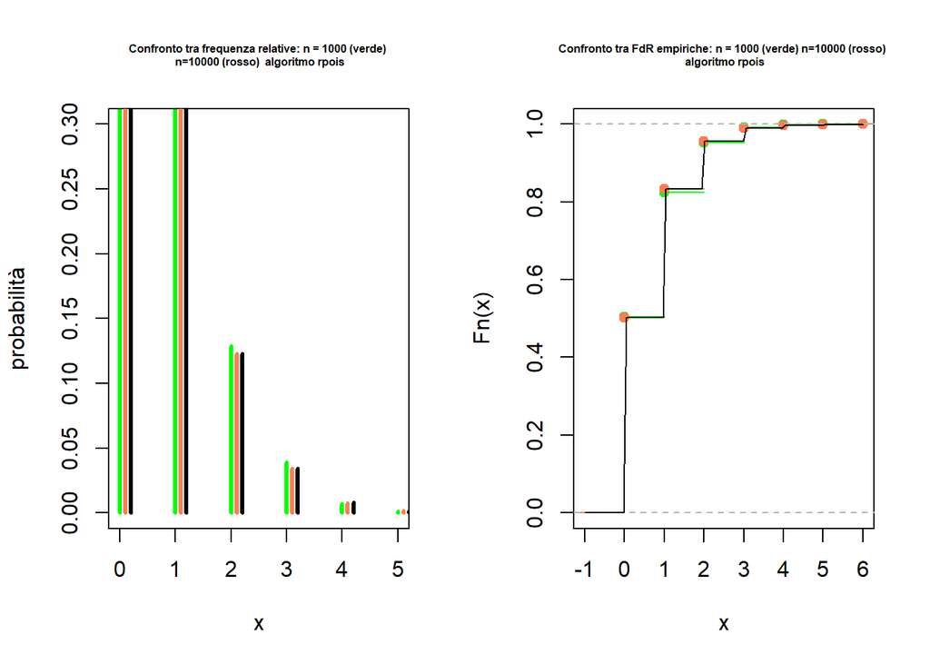

```r
tab1=table(det1)
tabo1=as.data.frame(tab1)
punti1 = as.numeric(levels(tabo1$det1))
freq1 = as.numeric(tab1/1000)

tab2=table(det2)
tabo2=as.data.frame(tab2)
punti2 = as.numeric(levels(tabo2$det2))
freq2 = as.numeric(tab2/10000)

# Confronto fra funzioni di densità
par(mfrow=c(1,2))
plot(punti1, freq1, type="h", col="green", ylab="probabilità", xlab="x",xlim=c(0,max(det1)), ylim=c(0,0.3), lwd=3, main="Confronto tra frequenza relative: n = 1000 (verde) \n n=10000 (rosso)  algoritmo rpois", cex.main=0.5)
points(punti2+.1, freq2, type="h", col="coral", lwd=3)
points(punti1+.2,dnbinom(punti1,alpha, p),type="h",col="black", lwd=3)

# Confronto fra funzioni di ripartizione
plot(ecdf(det1), col="green", main="Confronto tra FdR empiriche: n = 1000 (verde) n=10000 (rosso) \n algoritmo rpois",
cex.main=0.5)
plot(ecdf(det2), col="coral", add=T)
curve(pnbinom(x,alpha, p), col="black", add=TRUE)
```

## 8. Numeri generati da una poisson-composta

### 1000 determinazioni simulate con Wilson-Hilferty

```r
n=1000
alfa= 2000
beta= 0.5
lambda =  200
mu = lambda*alfa/beta
m2= alfa*(alfa+1)/(beta^2)
m3 = alfa*(alfa+1)*(alfa+2)/(beta^3)
sigma=sqrt(lambda*m2)
simm=m3/sqrt(lambda*(m2^3))
C1=simm/6-6/simm
C2= 3*((2/simm)^(2/3))
C3=2/simm

hinv= function(x){
  result = ((x-C1)^3)/(C2^3)-C3
  return (result)
}
```

```r
detnorm=rnorm(n, 0, 1)
det1WH=vector(mode="numeric")
det1WH = sigma*hinv(detnorm)+mu

## Indici sintetici
mean(det1WH)
```

```
## [1] 804587.6
```

```r
var(det1WH)
```

```
## [1] 3203751212
```

```r
## Media e varianza teorica
mu
```

```
## [1] 8e+05
```

```r
sigma^2
```

```
## [1] 3201600000
```

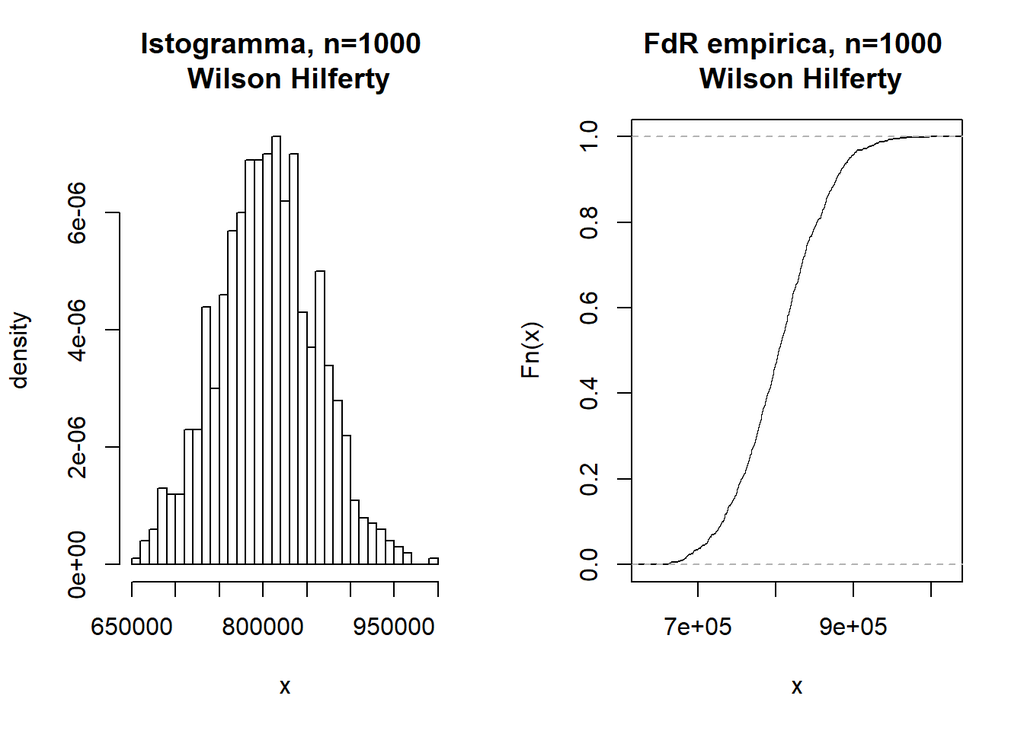

```r
par(mfrow=c(1,2))

## Istogramma
hist(det1WH, main="Istogramma, n=1000 \n Wilson Hilferty",  xlab="x", ylab="density", prob=T, breaks=30)

## Funzione di ripartizione empirica
plot(ecdf(det1WH), main="FdR empirica, n=1000 \n Wilson Hilferty",  xlab="x", ylab="Fn(x)")
```

### 10000 determinazioni simulate con Wilson Hilferty

```r
n=10000
alfa= 2000
beta= 0.5
lambda =  200
mu = lambda*alfa/beta
m2= alfa*(alfa+1)/(beta^2)
m3 = alfa*(alfa+1)*(alfa+2)/(beta^3)
sigma=sqrt(lambda*m2)
simm=m3/sqrt(lambda*(m2^3))
C1=simm/6-6/simm
C2= 3*((2/simm)^(2/3))
C3=2/simm

hinv= function(x){
  result = ((x-C1)^3)/(C2^3)-C3
  return (result)
}

detnorm=rnorm(n, 0, 1)
det2WH=vector(mode="numeric")
det2WH = sigma*hinv(detnorm)+mu

## Indici sintetici
mean(det2WH)
```

```
## [1] 800065.8
```

```r
var(det2WH)
```

```
## [1] 3143071189
```

```r
## Media e varianza teorica
mu
```

```
## [1] 8e+05
```

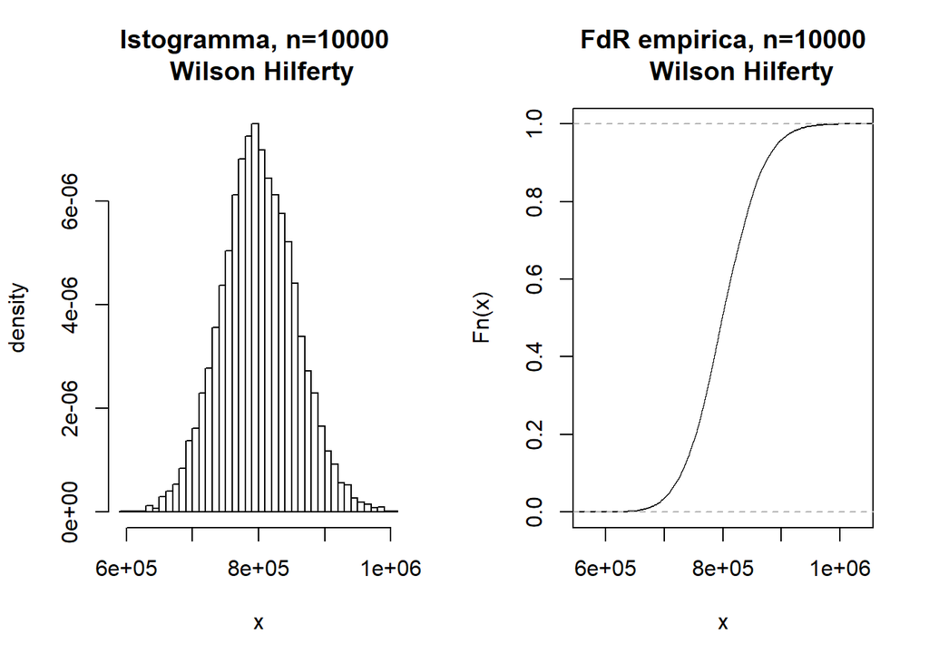

```r
par(mfrow=c(1,2))

## Istogramma
hist(det2WH, main="Istogramma, n=10000 \n Wilson Hilferty",  xlab="x", ylab="density", prob=T, breaks=40)

## Funzione di ripartizione empirica
plot(ecdf(det2WH), main="FdR empirica, n=10000
     Wilson Hilferty",  xlab="x", ylab="Fn(x)")
```

${\ F}_X\left(x\right)\cong\Phi\left(-\frac{3}{\gamma_X}+\sqrt{\frac{9}{\gamma_X^2}+1+\frac{6}{\gamma_X}\frac{x-\mu_X}{\vartheta_X}}\right),\ x>0$

```r
n=10000
alfa= 2000
beta= 0.5
lambda =  200
mu = lambda*alfa/beta
m2= alfa*(alfa+1)/(beta^2)
m3 = alfa*(alfa+1)*(alfa+2)/(beta^3)
sigma=sqrt(lambda*m2)

simm=m3/sqrt(lambda*(m2^3))
detnorm=rnorm(n, 0, 1)
det1NP=vector(mode="numeric")
det1NP = mu + sigma*detnorm +(sigma*simm)*(detnorm^2-1)/6

# Indici sintetici
mean(det1NP)
```

```
## [1] 800380.2
```

```r
var(det1NP)
```

```
## [1] 3219716498
```

```r
# Media e varianza teorica
mu
```

```
## [1] 8e+05
```

```r
sigma^2
```

```
## [1] 3201600000
```

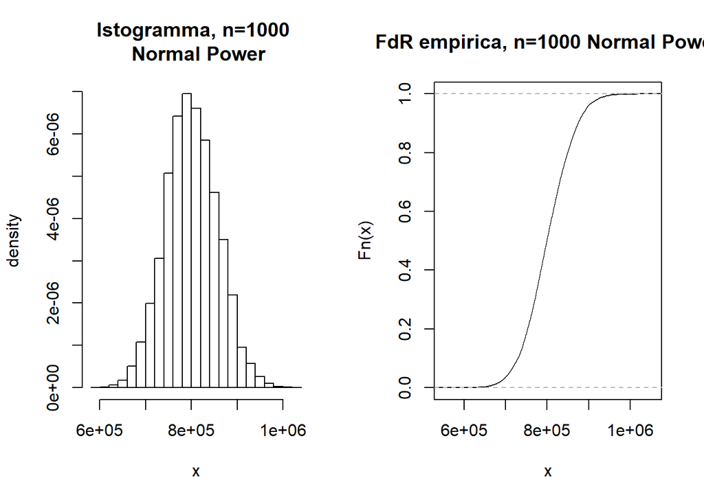

```r
par(mfrow=c(1,2))

# Istogramma
hist(det1NP, main="Istogramma, n=1000 \n Normal Power",  xlab="x", ylab="density", prob=T, breaks=30)
# Funzione di ripartizione empirica
plot(ecdf(det1NP), main="FdR empirica, n=1000 Normal Power",  xlab="x", ylab="Fn(x)")
```

### 10000 determinazioni simulate con Normal Power

${\ F}_X\left(x\right)\cong\Phi\left(-\frac{3}{\gamma_X}+\sqrt{\frac{9}{\gamma_X^2}+1+\frac{6}{\gamma_X}\frac{x-\mu_X}{\vartheta_X}}\right),\ x>0$

```r
n=10000
alfa= 2000
beta=0.5
lambda =  200

mu = lambda*alfa/beta
m2= alfa*(alfa+1)/(beta^2)
m3 = alfa*(alfa+1)*(alfa+2)/(beta^3)
sigma=sqrt(lambda*m2)
simm=m3/sqrt(lambda*(m2^3))
detnorm=rnorm(n, 0, 1)
det2NP=vector(mode="numeric")
det2NP = mu + sigma*detnorm +(sigma*simm)*(detnorm^2-1)/6

## Indici sintetici
mean(det2NP)
```

```
## [1] 800474.7
```

```r
var(det2NP)
```

```
## [1] 3222462165
```

```r
## Media e varianza teorica
mu
```

```
## [1] 8e+05
```

```r
sigma^2
```

```
## [1] 3201600000
```

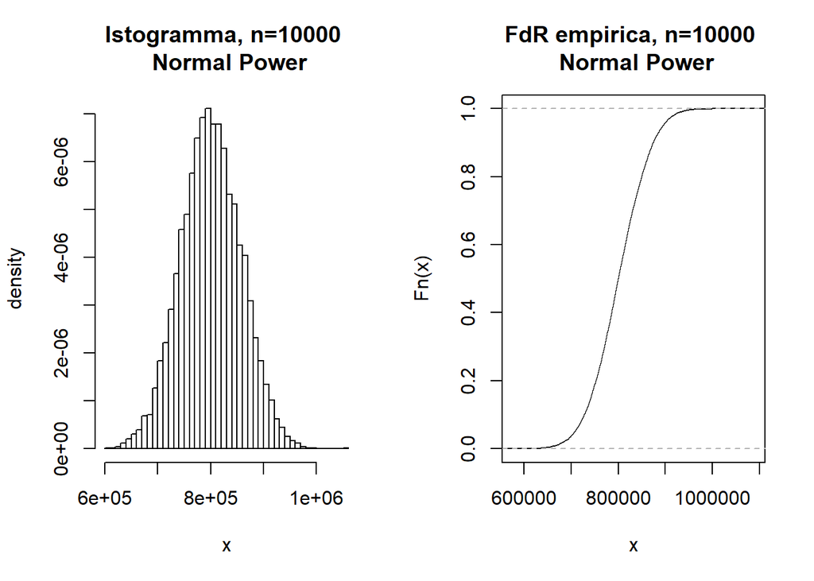

```r
par(mfrow=c(1,2))

## Istogramma
hist(det2NP, main="Istogramma, n=10000 \n Normal Power",  xlab="x", ylab="density", prob=T, breaks=40)
## Funzione di ripartizione empirica
plot(ecdf(det2NP), main="FdR empirica, n=10000 \n Normal Power",  xlab="x", ylab="Fn(x)")
```

### 1000 determinazioni simulate con procedimento diretto

```r
n=1000
alfa=2000
beta=0.5
lambda=200
det1=vector()
npois=vector()
for (i in 1:n){
  u = runif(1)
  npois[i]=qpois(u,lambda)
  if (npois[i]==0)
    det1[i]=0
    else{
      v=runif(npois[i])
      y=qgamma(v,alfa,beta)
      det1[i]=sum(y)
    }
  }

## Indici sintetici
mean(det1)
```

```
## [1] 799612.7
```

```r
var(det1)
```

```
## [1] 2959797968
```

```r
## Media e varianza teorica
mu
```

```
## [1] 8e+05
```

```r
sigma^2
```

```
## [1] 3201600000
```

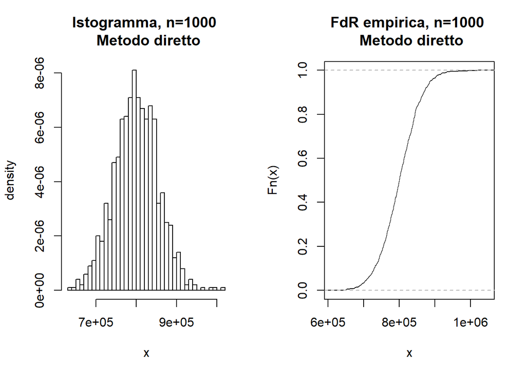

```r
par(mfrow=c(1,2))
## Istogramma
hist(det1, main="Istogramma, n=1000 \n Metodo diretto",  xlab="x", ylab="density", prob=T, breaks=30)

## Funzione di ripartizione empirica
plot(ecdf(det1), main="FdR empirica, n=1000 \n Metodo diretto",  xlab="x", ylab="Fn(x)")
```

### 10000 determinazioni simulate con procedimeto diretto

```r
n=10000
alfa=2000
beta=0.5
lambda=200
det2=vector()
npois=vector()

for (i in 1:n){
  u=runif(1)
  npois[i]=qpois(u,lambda)
    if (npois[i]==0)
      det2[i]=0
    else{
      v=runif(npois[i])
      y=qgamma(v,alfa,beta)
      det2[i]=sum(y)
    }
}

## Indici sintetici
mean(det1)
```

```
## [1] 799612.7
```

```r
var(det1)
```

```
## [1] 2959797968
```

```r
## Media e varianza teorica
mu
```

```
## [1] 8e+05
```

```r
sigma^2
```

```
## [1] 3201600000
```

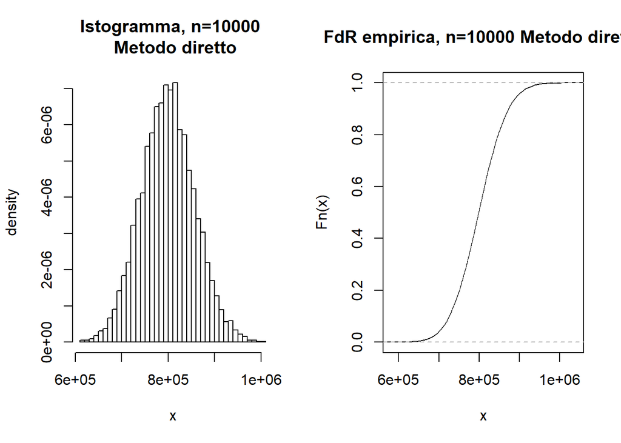

```r
par(mfrow=c(1,2))
## Istogramma
hist(det2, main="Istogramma, n=10000 \n Metodo diretto",  xlab="x", ylab="density", prob=T, breaks=40)

## Funzione di ripartizione empirica
plot(ecdf(det2), main="FdR empirica, n=10000 Metodo diretto",  xlab="x", ylab="Fn(x)")
```

### Confronti tra det1, det2, det1WH, det2WH, det1NP e det2NP

```r
# Medie empiriche
mean(det1)
```

```
## [1] 799612.7
```

```r
mean(det2)
```

```
## [1] 799257.3
```

```r
mean(det1WH)
```

```
## [1] 804587.6
```

```r
mean(det2WH)
```

```
## [1] 800065.8
```

```r
mean(det1NP)
```

```
## [1] 800380.2
```

```r
mean(det2NP)
```

```
## [1] 800474.7
```

```r
# Speranza matematica teorica:
mu
```

```
## [1] 8e+05
```

```r
# Varianza empirica
var(det1)
```

```
## [1] 2959797968
```

```r
var(det2)
```

```
## [1] 3284112483
```

```r
var(det1WH)
```

```
## [1] 3203751212
```

```r
var(det2WH)
```

```
## [1] 3143071189
```

```r
var(det1NP)
```

```
## [1] 3219716498
```

```r
var(det2NP)
```

```
## [1] 3222462165
```

```r
# Varianza teorica
sigma^2
```

```
## [1] 3201600000
```

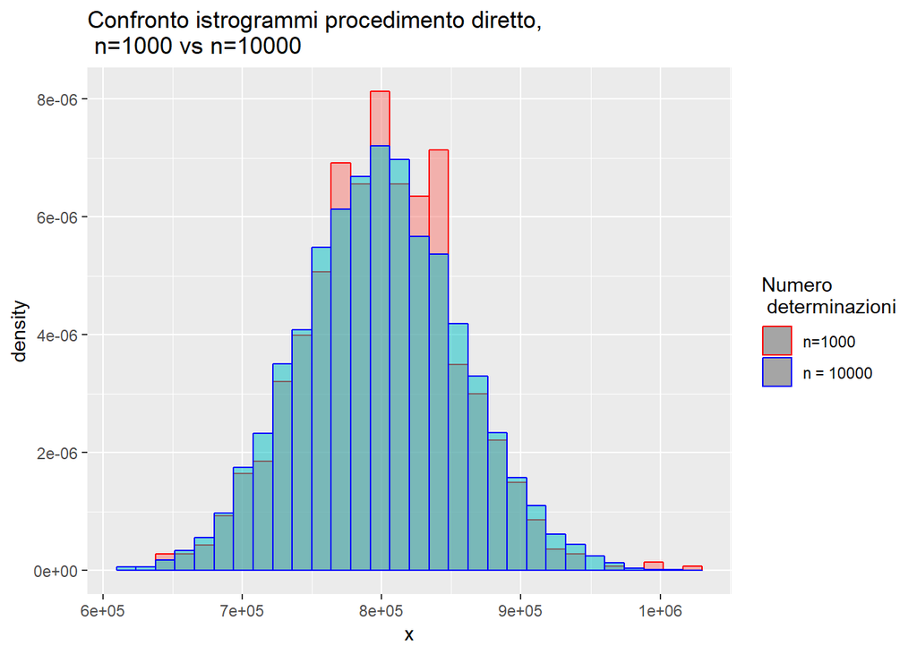

```r
# Confronto istogrammi con determinazioni simulate mediante metodo diretto n=1000 vs n=10000
data1=data.frame(x=det1)
data2=data.frame(x=det2)
data1$veg = 'x1'
data2$veg = 'y1'
pippo= rbind(data1,data2)
ggplot(pippo,aes(x, color=veg)) +
  geom_histogram(alpha=0.5,aes(y=..density.., fill=veg), position = 'identity') + guides(fill=F)+ scale_colour_manual(name="Numero \n determinazioni",values=c("red","blue"), labels=c("x1"="n=1000", "y1"="n = 10000"))+
  ggtitle("Confronto istrogrammi procedimento diretto, \n n=1000 vs n=10000")
```

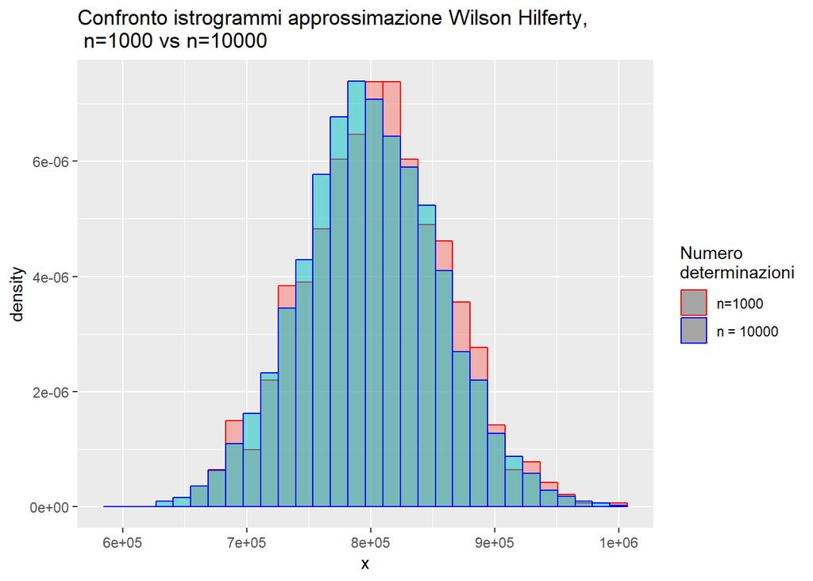

```r
# Confronto istogrammi con determinazioni simulate mediante approssimazione Wilson Hilferty, n=1000 vs n=10000
data1WH=data.frame(x=det1WH)
data2WH=data.frame(x=det2WH)
data1WH$veg = 'x1'
data2WH$veg = 'y1'
ciao= rbind(data1WH,data2WH)
ggplot(ciao,aes(x, color=veg)) +
  geom_histogram(alpha=0.5,aes(y=..density.., fill=veg), position = 'identity') +
  guides(fill=F)+
  scale_colour_manual(name="Numero\ndeterminazioni",values=c("red","blue"), labels=c("x1"="n=1000", "y1"="n = 10000"))+
  ggtitle("Confronto istrogrammi approssimazione Wilson Hilferty, \n n=1000 vs n=10000")
```

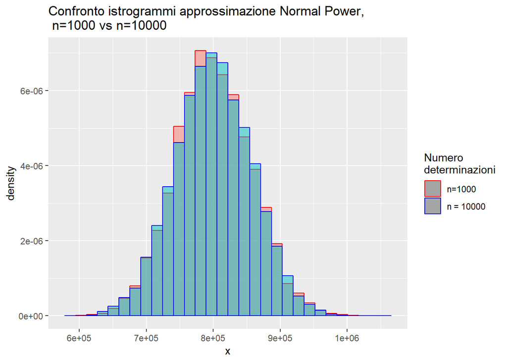

```r
### Confronto istogrammi con determinazioni simulate mediante approssimazione Wilson Hilferty, n=1000 vs n=10000
data1NP=data.frame(x=det1NP)
data2NP=data.frame(x=det2NP)
data1NP$veg = 'x1'
data2NP$veg = 'y1'
ciao= rbind(data1NP,data2NP)
ggplot(ciao,aes(x, color=veg)) +
  geom_histogram(alpha=0.5,aes(y=..density.., fill=veg), position = 'identity') +
  guides(fill=F)+
  scale_colour_manual(name="Numero\ndeterminazioni",values=c("red","blue"), labels=c("x1"="n=1000", "y1"="n = 10000"))+
  ggtitle("Confronto istrogrammi approssimazione Normal Power, \n n=1000 vs n=10000")
```

# Esercizio sulla probabilità di rovina

Consegna: Valutare, mediante simulazione, la probabilità di rovina in un orizzonte limitato, nel modello della teoria collettiva del rischio (TCR).

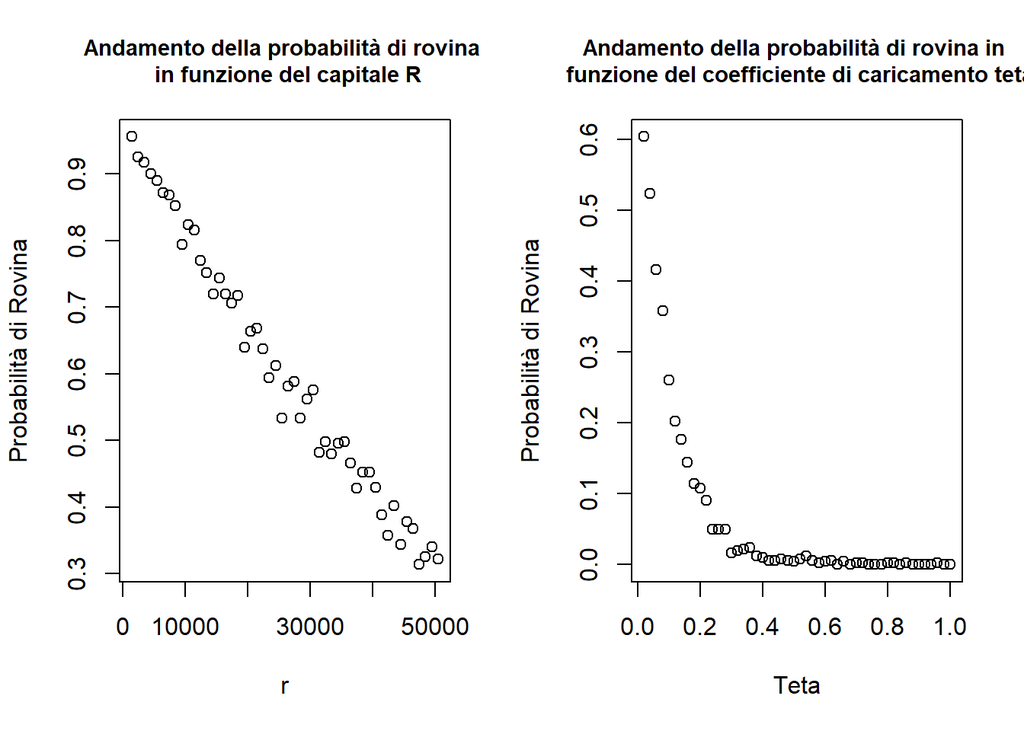

```r
probrov = function(R, tau, lambda, alfa, beta, teta, n){
  mu=alfa/beta
  c=(1+teta)*lambda*mu
  det=vector()
  for (i in 1:n){
    ta=0
    d=0
    det[i]=0
    while (!det[i]==1) {
      u=runif(1)
      w=-(1/lambda)*log(u)
      tb=ta+w

      if (tb>tau)
      {break}
      else {
        u=runif(1)
        y=qgamma(u, alfa, beta)
        d=d+c*(tb-ta)-y
        if (d<(-1)*R)
          det[i]=1
        else
          ta=tb
      }
    }
  }
  rovina=sum(det)/n
  return(rovina)
}

par(mfrow=c(1,2))
## Fissiamo tutti i valori e vediamo come varia la probabilità di rovina in funzione del capitale R
varR=vector()
r=vector()
for (i in 1:50){
  r[i]=500+1000*i
  varR[i]=probrov(r[i],20,20,2000,0.5,0.03, 500)
}
plot(r, varR, main="Andamento della probabilità di rovina \n in funzione del capitale R", ylab="Probabilità di Rovina", cex.main=0.9)
## Fissiamo tutti i valori e vediamo come varia la probabilità di rovina in funzione del coefficiente di caricamento di sicurezza teta
m=mean(r)
varTeta=vector()
Teta=vector()
for (i in 1:50){
  Teta[i]= 0.02*i
  varTeta[i]=probrov(m,20,20,2000,0.5, Teta[i], 500)
}
plot(Teta, varTeta, main="Andamento della probabilità di rovina in \n funzione del coefficiente di caricamento teta", ylab="Probabilità di Rovina", cex.main=0.9)
```